# LCS bivariate model results

```r
# Murkse script
# Jacobs study
#
# written by Johannes Falck
# contact: johannes.falck89@gmail.com
# last time script was modified
last_modified <- file.mtime(paste(rstudioapi::getActiveDocumentContext()$path))

# initialise ####
# load packages
library(lavaan);library(moments); library(car);library(psych); library(metaSEM);library(tidySEM);library(bbmle); library(ggplot2)

# set wd from script file path


# load data
load("model.data.selected.rda")
```

Development of Learning rates from positive and negative feedback

# Hypotheses

1. BASELINE: negative LR is higher than positive LR
2. CHANGE: no clear assumption about change. positive LR changes later (after 11 years), so an increase in positive LR is unlikely.

```r
'further ideas
3) brain development might influence the cognitive development. A normative brain development might be in line with the hypotheses, whereas aberrant brain development might defer in cognitive development. No assumptions are made regarding striatal development, as the study window is believed to be after the striatal growth
3a) As hippocampal growth is expected, less growth in the study window might relate to less increase in LRs
3b) As hippocampal growth is expected, less growth might relate to less positive baseline relationship with LRs'
```

```
[1] "further ideas\n3) brain development might influence the cognitive development. A normative brain development might be in line with the hypotheses, whereas aberrant brain development might defer in cognitive development. No assumptions are made regarding striatal development, as the study window…
```

# Plots

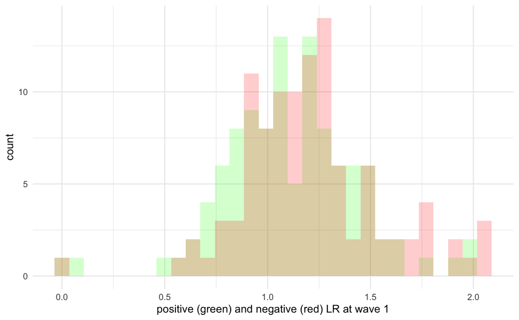

```r
ggplot(data=model.data)+theme_minimal()+ xlab("positive (green) and negative (red) LR at wave 1")+
  geom_histogram(mapping = aes(x=LR_pos_w1_new_t),alpha=.2,fill="green")+
  geom_histogram(mapping = aes(x=LR_neg_w1_new_t),alpha=.2,fill="red")
```

```
Warnung: Removed 11 rows containing non-finite values (stat_bin).
Warnung: Removed 11 rows containing non-finite values (stat_bin).
```

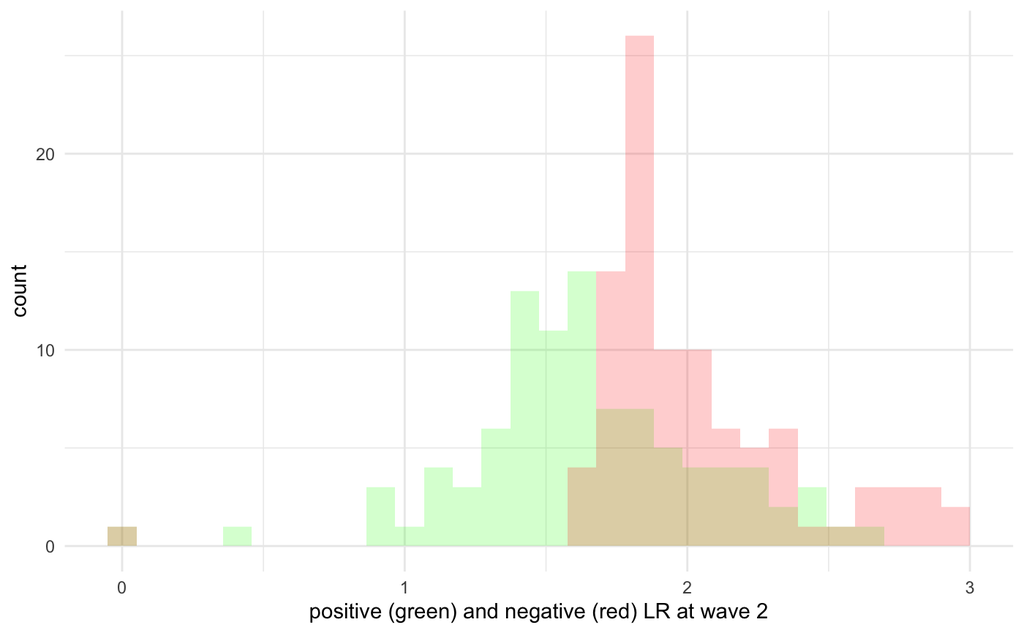

```r
ggplot(data=model.data)+theme_minimal()+ xlab("positive (green) and negative (red) LR at wave 2")+
  geom_histogram(mapping = aes(x=LR_pos_w2_new_t),alpha=.2,fill="green")+
  geom_histogram(mapping = aes(x=LR_neg_w2_new_t),alpha=.2,fill="red")
```

# Models

```r
# M0 bivariate LR pos/neg model ####
#### full model ####
LCS_bivariate_lr_pos_neg<-"
! regressions
LR_pos_w2_new_t ~ 1*LR_pos_w1_new_t
dLR_pos =~ 1*LR_pos_w2_new_t
dLR_pos ~ LR_pos_w1_new_t

LR_neg_w2_new_t ~ 1*LR_neg_w1_new_t
dLR_neg =~ 1*LR_neg_w2_new_t
dLR_neg ~ LR_neg_w1_new_t

# cross domain links
dLR_neg ~ LR_pos_w1_new_t
dLR_pos ~ LR_neg_w1_new_t
dLR_pos ~~ dLR_neg
LR_neg_w1_new_t ~~ LR_pos_w1_new_t

! means
dLR_pos ~ c*1
dLR_neg ~ d*1
LR_pos_w1_new_t ~  a*1
LR_neg_w1_new_t ~  b*1
LR_pos_w2_new_t ~ 0*1
LR_neg_w2_new_t ~ 0*1
age ~ 0*1
sex ~ 1
baseline effect := a-b
change effect := c-d

! residuals, variances and covariances
dLR_neg ~~ age
dLR_neg ~~ sex
dLR_pos ~~ age
dLR_pos ~~ sex

age ~~ LR_pos_w1_new_t
sex ~~ LR_pos_w1_new_t

age ~~ LR_neg_w1_new_t
sex ~~ LR_neg_w1_new_t

age ~~ age
sex ~~ sex
sex ~~ age

dLR_pos ~~ dLR_pos
dLR_neg ~~ dLR_neg
LR_pos_w1_new_t ~~ LR_pos_w1_new_t
LR_neg_w1_new_t ~~ LR_neg_w1_new_t
LR_pos_w2_new_t ~~ 0*LR_pos_w2_new_t
LR_neg_w2_new_t ~~ 0*LR_neg_w2_new_t
"
```

```r
#### equality constrain change####
LCS_bivariate_lr_pos_neg_equal<-"
! regressions
LR_pos_w2_new_t ~ 1*LR_pos_w1_new_t
dLR_pos =~ 1*LR_pos_w2_new_t
dLR_pos ~ LR_pos_w1_new_t

LR_neg_w2_new_t ~ 1*LR_neg_w1_new_t
dLR_neg =~ 1*LR_neg_w2_new_t
dLR_neg ~ LR_neg_w1_new_t

# cross domain links
dLR_neg ~ LR_pos_w1_new_t
dLR_pos ~ LR_neg_w1_new_t
dLR_pos ~~ dLR_neg
LR_neg_w1_new_t ~~ LR_pos_w1_new_t

! means
dLR_pos ~ cov*1
dLR_neg ~ cov*1
LR_pos_w1_new_t ~  1
LR_neg_w1_new_t ~  1
LR_pos_w2_new_t ~ 0*1
LR_neg_w2_new_t ~ 0*1
age ~ 0*1
sex ~ 1

! residuals, variances and covariances
dLR_neg ~~ age
dLR_neg ~~ sex
dLR_pos ~~ age
dLR_pos ~~ sex

age ~~ LR_pos_w1_new_t
sex ~~ LR_pos_w1_new_t

age ~~ LR_neg_w1_new_t
sex ~~ LR_neg_w1_new_t

age ~~ age
sex ~~ sex
sex ~~ age

dLR_pos ~~ dLR_pos
dLR_neg ~~ dLR_neg
LR_pos_w1_new_t ~~ LR_pos_w1_new_t
LR_neg_w1_new_t ~~ LR_neg_w1_new_t
LR_pos_w2_new_t ~~ 0*LR_pos_w2_new_t
LR_neg_w2_new_t ~~ 0*LR_neg_w2_new_t
"
```

```r
#### equality constrain baseline ####
LCS_bivariate_lr_pos_neg_intequal<-"
! regressions
LR_pos_w2_new_t ~ 1*LR_pos_w1_new_t
dLR_pos =~ 1*LR_pos_w2_new_t
dLR_pos ~ LR_pos_w1_new_t

LR_neg_w2_new_t ~ 1*LR_neg_w1_new_t
dLR_neg =~ 1*LR_neg_w2_new_t
dLR_neg ~ LR_neg_w1_new_t

# cross domain links
dLR_neg ~ LR_pos_w1_new_t
dLR_pos ~ LR_neg_w1_new_t
dLR_pos ~~ dLR_neg
LR_neg_w1_new_t ~~ LR_pos_w1_new_t

! means
dLR_pos ~ 1
dLR_neg ~ 1
LR_pos_w1_new_t ~  cov*1
LR_neg_w1_new_t ~  cov*1
LR_pos_w2_new_t ~ 0*1
LR_neg_w2_new_t ~ 0*1
age ~ 0*1
sex ~ 1

! residuals, variances and covariances
dLR_neg ~~ age
dLR_neg ~~ sex
dLR_pos ~~ age
dLR_pos ~~ sex

age ~~ LR_pos_w1_new_t
sex ~~ LR_pos_w1_new_t

age ~~ LR_neg_w1_new_t
sex ~~ LR_neg_w1_new_t

age ~~ age
sex ~~ sex
sex ~~ age

dLR_pos ~~ dLR_pos
dLR_neg ~~ dLR_neg
LR_pos_w1_new_t ~~ LR_pos_w1_new_t
LR_neg_w1_new_t ~~ LR_neg_w1_new_t
LR_pos_w2_new_t ~~ 0*LR_pos_w2_new_t
LR_neg_w2_new_t ~~ 0*LR_neg_w2_new_t
"
```

```r
#### 0-constrain LR_pos change ####
LCS_bivariate_lr_pos0<-"
! regressions
LR_pos_w2_new_t ~ 1*LR_pos_w1_new_t
dLR_pos =~ 1*LR_pos_w2_new_t
dLR_pos ~ LR_pos_w1_new_t

LR_neg_w2_new_t ~ 1*LR_neg_w1_new_t
dLR_neg =~ 1*LR_neg_w2_new_t
dLR_neg ~ LR_neg_w1_new_t

# cross domain links
dLR_neg ~ LR_pos_w1_new_t
dLR_pos ~ LR_neg_w1_new_t
dLR_pos ~~ dLR_neg
LR_neg_w1_new_t ~~ LR_pos_w1_new_t

! means
dLR_pos ~ 0*1
dLR_neg ~ 1
LR_pos_w1_new_t ~  1
LR_neg_w1_new_t ~  1
LR_pos_w2_new_t ~ 0*1
LR_neg_w2_new_t ~ 0*1
age ~ 0*1
sex ~ 1

! residuals, variances and covariances
dLR_neg ~~ age
dLR_neg ~~ sex
dLR_pos ~~ age
dLR_pos ~~ sex

age ~~ LR_pos_w1_new_t
sex ~~ LR_pos_w1_new_t

age ~~ LR_neg_w1_new_t
sex ~~ LR_neg_w1_new_t

age ~~ age
sex ~~ sex
sex ~~ age

dLR_pos ~~ dLR_pos
dLR_neg ~~ dLR_neg
LR_pos_w1_new_t ~~ LR_pos_w1_new_t
LR_neg_w1_new_t ~~ LR_neg_w1_new_t
LR_pos_w2_new_t ~~ 0*LR_pos_w2_new_t
LR_neg_w2_new_t ~~ 0*LR_neg_w2_new_t
"
```

```r
#### 0-constrain LR_pos baseline ####
LCS_bivariate_lr_pos_int0<-"
! regressions
LR_pos_w2_new_t ~ 1*LR_pos_w1_new_t
dLR_pos =~ 1*LR_pos_w2_new_t
dLR_pos ~ LR_pos_w1_new_t

LR_neg_w2_new_t ~ 1*LR_neg_w1_new_t
dLR_neg =~ 1*LR_neg_w2_new_t
dLR_neg ~ LR_neg_w1_new_t

# cross domain links
dLR_neg ~ LR_pos_w1_new_t
dLR_pos ~ LR_neg_w1_new_t
dLR_pos ~~ dLR_neg
LR_neg_w1_new_t ~~ LR_pos_w1_new_t

! means
dLR_pos ~ 1
dLR_neg ~ 1
LR_pos_w1_new_t ~  0*1
LR_neg_w1_new_t ~  1
LR_pos_w2_new_t ~ 0*1
LR_neg_w2_new_t ~ 0*1
age ~ 0*1
sex ~ 1

! residuals, variances and covariances
dLR_neg ~~ age
dLR_neg ~~ sex
dLR_pos ~~ age
dLR_pos ~~ sex

age ~~ LR_pos_w1_new_t
sex ~~ LR_pos_w1_new_t

age ~~ LR_neg_w1_new_t
sex ~~ LR_neg_w1_new_t

age ~~ age
sex ~~ sex
sex ~~ age

dLR_pos ~~ dLR_pos
dLR_neg ~~ dLR_neg
LR_pos_w1_new_t ~~ LR_pos_w1_new_t
LR_neg_w1_new_t ~~ LR_neg_w1_new_t
LR_pos_w2_new_t ~~ 0*LR_pos_w2_new_t
LR_neg_w2_new_t ~~ 0*LR_neg_w2_new_t
"
```

```r
#### 0-constrain both baselines ####
LCS_bivariate_lr_int0<-"
! regressions
LR_pos_w2_new_t ~ 1*LR_pos_w1_new_t
dLR_pos =~ 1*LR_pos_w2_new_t
dLR_pos ~ LR_pos_w1_new_t

LR_neg_w2_new_t ~ 1*LR_neg_w1_new_t
dLR_neg =~ 1*LR_neg_w2_new_t
dLR_neg ~ LR_neg_w1_new_t

# cross domain links
dLR_neg ~ LR_pos_w1_new_t
dLR_pos ~ LR_neg_w1_new_t
dLR_pos ~~ dLR_neg
LR_neg_w1_new_t ~~ LR_pos_w1_new_t

! means
dLR_pos ~ 1
dLR_neg ~ 1
LR_pos_w1_new_t ~  0*1
LR_neg_w1_new_t ~  0*1
LR_pos_w2_new_t ~ 0*1
LR_neg_w2_new_t ~ 0*1
age ~ 0*1
sex ~ 1

! residuals, variances and covariances
dLR_neg ~~ age
dLR_neg ~~ sex
dLR_pos ~~ age
dLR_pos ~~ sex

age ~~ LR_pos_w1_new_t
sex ~~ LR_pos_w1_new_t

age ~~ LR_neg_w1_new_t
sex ~~ LR_neg_w1_new_t

age ~~ age
sex ~~ sex
sex ~~ age

dLR_pos ~~ dLR_pos
dLR_neg ~~ dLR_neg
LR_pos_w1_new_t ~~ LR_pos_w1_new_t
LR_neg_w1_new_t ~~ LR_neg_w1_new_t
LR_pos_w2_new_t ~~ 0*LR_pos_w2_new_t
LR_neg_w2_new_t ~~ 0*LR_neg_w2_new_t
"
```

```r
#### 0-constrain LR_neg change ####
LCS_bivariate_lr_neg0<-"
! regressions
LR_pos_w2_new_t ~ 1*LR_pos_w1_new_t
dLR_pos =~ 1*LR_pos_w2_new_t
dLR_pos ~ LR_pos_w1_new_t

LR_neg_w2_new_t ~ 1*LR_neg_w1_new_t
dLR_neg =~ 1*LR_neg_w2_new_t
dLR_neg ~ LR_neg_w1_new_t

# cross domain links
dLR_neg ~ LR_pos_w1_new_t
dLR_pos ~ LR_neg_w1_new_t
dLR_pos ~~ dLR_neg
LR_neg_w1_new_t ~~ LR_pos_w1_new_t

! means
dLR_pos ~ 1
dLR_neg ~ 0*1
LR_pos_w1_new_t ~  1
LR_neg_w1_new_t ~  1
LR_pos_w2_new_t ~ 0*1
LR_neg_w2_new_t ~ 0*1
age ~ 0*1
sex ~ 1

! residuals, variances and covariances
dLR_neg ~~ age
dLR_neg ~~ sex
dLR_pos ~~ age
dLR_pos ~~ sex

age ~~ LR_pos_w1_new_t
sex ~~ LR_pos_w1_new_t

age ~~ LR_neg_w1_new_t
sex ~~ LR_neg_w1_new_t

age ~~ age
sex ~~ sex
sex ~~ age

dLR_pos ~~ dLR_pos
dLR_neg ~~ dLR_neg
LR_pos_w1_new_t ~~ LR_pos_w1_new_t
LR_neg_w1_new_t ~~ LR_neg_w1_new_t
LR_pos_w2_new_t ~~ 0*LR_pos_w2_new_t
LR_neg_w2_new_t ~~ 0*LR_neg_w2_new_t
"
```

```r
#### 0-constrain LR_neg baseline ####
LCS_bivariate_lr_neg_int0<-"
! regressions
LR_pos_w2_new_t ~ 1*LR_pos_w1_new_t
dLR_pos =~ 1*LR_pos_w2_new_t
dLR_pos ~ LR_pos_w1_new_t

LR_neg_w2_new_t ~ 1*LR_neg_w1_new_t
dLR_neg =~ 1*LR_neg_w2_new_t
dLR_neg ~ LR_neg_w1_new_t

# cross domain links
dLR_neg ~ LR_pos_w1_new_t
dLR_pos ~ LR_neg_w1_new_t
dLR_pos ~~ dLR_neg
LR_neg_w1_new_t ~~ LR_pos_w1_new_t

! means
dLR_pos ~ 1
dLR_neg ~ 1
LR_pos_w1_new_t ~  1
LR_neg_w1_new_t ~  0*1
LR_pos_w2_new_t ~ 0*1
LR_neg_w2_new_t ~ 0*1
age ~ 0*1
sex ~ 1

! residuals, variances and covariances
dLR_neg ~~ age
dLR_neg ~~ sex
dLR_pos ~~ age
dLR_pos ~~ sex

age ~~ LR_pos_w1_new_t
sex ~~ LR_pos_w1_new_t

age ~~ LR_neg_w1_new_t
sex ~~ LR_neg_w1_new_t

age ~~ age
sex ~~ sex
sex ~~ age

dLR_pos ~~ dLR_pos
dLR_neg ~~ dLR_neg
LR_pos_w1_new_t ~~ LR_pos_w1_new_t
LR_neg_w1_new_t ~~ LR_neg_w1_new_t
LR_pos_w2_new_t ~~ 0*LR_pos_w2_new_t
LR_neg_w2_new_t ~~ 0*LR_neg_w2_new_t
"
```

# Full model

```r
#### summary ####
fitLCS_bivariate_lr_pos_neg <- lavaan(LCS_bivariate_lr_pos_neg, data=model.data, estimator='mlr', fixed.x=FALSE,missing='fiml', test="bootstrap")
sum.table <- summary(fitLCS_bivariate_lr_pos_neg, fit.measures=TRUE, standardized=TRUE, rsquare=TRUE)$PE
```

```
lavaan 0.6-8 ended normally after 51 iterations

  Estimator                                         ML
  Optimization method                           NLMINB
  Number of model parameters                        26

  Number of observations                           106
  Number of missing patterns                         2

Model Test User Model:
                                               Standard      Robust
  Test Statistic                                  0.025       0.025
  Degrees of freedom                                  1           1
  P-value (Chi-square)                            0.874       0.873
  Scaling correction factor                                   0.988
       Yuan-Bentler correction (Mplus variant)

Model Test Baseline Model:

  Test statistic                                19.655      15.851
  Degrees of freedom                                15          15
  P-value                                        0.186       0.392
  Scaling correction factor                                  1.240

User Model versus Baseline Model:

  Comparative Fit Index (CFI)                    1.000       1.000
  Tucker-Lewis Index (TLI)                       4.142      18.171

  Robust Comparative Fit Index (CFI)                         1.000
  Robust Tucker-Lewis Index (TLI)                           14.684

Loglikelihood and Information Criteria:

  Loglikelihood user model (H0)               -464.719    -464.719
  Scaling correction factor                                  1.288
      for the MLR correction
  Loglikelihood unrestricted model (H1)       -464.707    -464.707
  Scaling correction factor                                  1.277
      for the MLR correction
```

[output cut: 86 more lines]

```
    LR_neg_w1_nw_t    0.114    0.020    5.762    0.000    0.114    1.000
   .LR_pos_w2_nw_t    0.000                               0.000    0.000
   .LR_neg_w2_nw_t    0.000                               0.000    0.000

R-Square:
                   Estimate
    dLR_pos           0.336
    dLR_neg           0.422
    LR_pos_w2_nw_t    1.000
    LR_neg_w2_nw_t    1.000

Defined Parameters:
                   Estimate  Std.Err  z-value  P(>|z|)   Std.lv  Std.all
    baselineeffect   -0.095    0.048   -1.977    0.048   -0.095   -0.209
    changeeffect     -0.378    0.239   -1.584    0.113   -0.802   -0.802
```

```r
sum.table <- sum.table[c(3,6:14),c(1:3,6:9)]
sum.table
```

|  | lhs | op | rhs | est | se | z | pvalue |
| --- | --- | --- | --- | --- | --- | --- | --- |
| 3 | dLR_pos | ~ | LR_pos_w1_new_t | -0.93368 | 0.1433 | -6.515 | 7.28e-11 |
| 6 | dLR_neg | ~ | LR_neg_w1_new_t | -0.99257 | 0.1080 | -9.193 | 0.00e+00 |
| 7 | dLR_neg | ~ | LR_pos_w1_new_t | 0.06181 | 0.1623 | 0.381 | 7.03e-01 |
| 8 | dLR_pos | ~ | LR_neg_w1_new_t | 0.00866 | 0.1293 | 0.067 | 9.47e-01 |
| 9 | dLR_pos | ~~ | dLR_neg | 0.04122 | 0.0242 | 1.704 | 8.85e-02 |
| 10 | LR_pos_w1_new_t | ~~ | LR_neg_w1_new_t | -0.01164 | 0.0148 | -0.787 | 4.31e-01 |
| 11 | dLR_pos | ~1 |  | 1.55758 | 0.2048 | 7.606 | 2.82e-14 |
| 12 | dLR_neg | ~1 |  | 1.93599 | 0.2420 | 7.999 | 1.33e-15 |
| 13 | LR_pos_w1_new_t | ~1 |  | 1.11139 | 0.0313 | 35.523 | 0.00e+00 |
| 14 | LR_neg_w1_new_t | ~1 |  | 1.20633 | 0.0329 | 36.653 | 0.00e+00 |

Effect size between LRs for baseline and change

```r
# effect size for baseline
# calculated according to Cheung (2018) doi.org/10.3389/fpsyg.2018.01387
cov <- inspectSampleCov(model = fitLCS_bivariate_lr_pos_neg, data = model.data)$cov
mean <- inspectSampleCov(model = fitLCS_bivariate_lr_pos_neg, data = model.data)$mean
calEffSizes(model = fitLCS_bivariate_lr_pos_neg,n = 140, Cov = cov,Mean = mean,lavaan.output = F)$ES
```

```
baselineeffect   changeeffect
       -0.0819        -0.3765
```

–> result: significant effect at baseline, negative LR higher

# baseline mean

equal constraining both LRs mean baseline

```r
fitLCS_bivariate_lr_pos_neg_intequal <- lavaan(LCS_bivariate_lr_pos_neg_intequal, data=model.data, estimator='mlr', fixed.x=FALSE,missing='fiml', test="bootstrap")
#summary(fitLCS_bivariate_lr_pos_neg_intequal, fit.measures=TRUE, standardized=TRUE, rsquare=TRUE)
anova(fitLCS_bivariate_lr_pos_neg,fitLCS_bivariate_lr_pos_neg_intequal)
```

```
Scaled Chi-Squared Difference Test (method = “satorra.bentler.2001”)

lavaan NOTE:
    The “Chisq” column contains standard test statistics, not the
    robust test that should be reported per model. A robust difference
    test is a function of two standard (not robust) statistics.

                                     Df AIC  BIC Chisq Chisq diff Df diff Pr(>Chisq)
fitLCS_bivariate_lr_pos_neg           1 981 1051  0.03
fitLCS_bivariate_lr_pos_neg_intequal  2 983 1050  3.88        3.5       1      0.061 .
---
Signif. codes:  0 ‘***’ 0.001 ‘**’ 0.01 ‘*’ 0.05 ‘.’ 0.1 ‘ ’ 1
```

0 constraining positive LR mean baseline

```r
fitLCS_bivariate_lr_pos_int0 <- lavaan(LCS_bivariate_lr_pos_int0, data=model.data, estimator='mlr', fixed.x=FALSE,missing='fiml', test="bootstrap")
```

0 constraining negative LR baseline mean

```r
fitLCS_bivariate_lr_neg_int0 <- lavaan(LCS_bivariate_lr_neg_int0, data=model.data, estimator='mlr', fixed.x=FALSE,missing='fiml', test="bootstrap")
#summary(fitLCS_bivariate_lr_neg_int0, fit.measures=TRUE, standardized=TRUE, rsquare=TRUE)
anova(fitLCS_bivariate_lr_neg_int0,fitLCS_bivariate_lr_pos_neg)
```

```
Scaled Chi-Squared Difference Test (method = “satorra.bentler.2001”)

lavaan NOTE:
    The “Chisq” column contains standard test statistics, not the
    robust test that should be reported per model. A robust difference
    test is a function of two standard (not robust) statistics.

                             Df  AIC  BIC  Chisq Chisq diff Df diff Pr(>Chisq)
fitLCS_bivariate_lr_pos_neg   1  981 1051   0.03
fitLCS_bivariate_lr_neg_int0  2 1258 1324 278.20        118       1     <2e-16 ***
---
Signif. codes:  0 ‘***’ 0.001 ‘**’ 0.01 ‘*’ 0.05 ‘.’ 0.1 ‘ ’ 1
```

dAIC for 0-constraining baseline mean of positive LR vs negative LR

```r
# results table
mc_pos_neg <- as.data.frame(anova(fitLCS_bivariate_lr_pos_int0,fitLCS_bivariate_lr_neg_int0)[c(1:3)])
mc_pos_neg$dAIC <- unlist(AICtab(fitLCS_bivariate_lr_pos_int0,fitLCS_bivariate_lr_neg_int0)[c(1)])
mc_pos_neg$dBIC <- unlist(BICtab(fitLCS_bivariate_lr_pos_int0,fitLCS_bivariate_lr_neg_int0)[c(1)])
mc_pos_neg$restricted <- c("LR pos baseline","LR neg baseline")

mc_pos_neg
```

|  | Df | AIC | BIC | dAIC | dBIC | restricted |
| --- | --- | --- | --- | --- | --- | --- |
| fitLCS_bivariate_lr_pos_int0 | 2 | 1251 | 1317 | 0.00 | 0.00 | LR pos baseline |
| fitLCS_bivariate_lr_neg_int0 | 2 | 1258 | 1324 | 6.84 | 6.84 | LR neg baseline |

```r
#dev.off()
#gridExtra::grid.table(mc_pos_neg)
```

–> model comparison confirms effect between baseline means, where negative LR shows a higher baseline mean –> in line with hypothesis

# change mean

equal constraining both LRs mean change

```r
fitLCS_bivariate_lr_pos_neg_equal <- lavaan(LCS_bivariate_lr_pos_neg_equal, data=model.data, estimator='mlr', fixed.x=FALSE,missing='fiml', test="bootstrap")
#summary(fitLCS_bivariate_lr_pos_neg_equal, fit.measures=TRUE, standardized=TRUE, rsquare=TRUE)
anova(fitLCS_bivariate_lr_pos_neg,fitLCS_bivariate_lr_pos_neg_equal)
```

```
Scaled Chi-Squared Difference Test (method = “satorra.bentler.2001”)

lavaan NOTE:
    The “Chisq” column contains standard test statistics, not the
    robust test that should be reported per model. A robust difference
    test is a function of two standard (not robust) statistics.

                                  Df AIC  BIC Chisq Chisq diff Df diff Pr(>Chisq)
fitLCS_bivariate_lr_pos_neg        1 981 1051  0.03
fitLCS_bivariate_lr_pos_neg_equal  2 981 1048  1.72       3.24       1      0.072 .
---
Signif. codes:  0 ‘***’ 0.001 ‘**’ 0.01 ‘*’ 0.05 ‘.’ 0.1 ‘ ’ 1
```

0 constraining positive LR mean change

```r
fitLCS_bivariate_lr_pos0 <- lavaan(LCS_bivariate_lr_pos0, data=model.data, estimator='mlr', fixed.x=FALSE,missing='fiml', test="bootstrap")
#summary(fitLCS_bivariate_lr_pos0, fit.measures=TRUE, standardized=TRUE, rsquare=TRUE)
anova(fitLCS_bivariate_lr_pos_neg,fitLCS_bivariate_lr_pos0)
```

```
Scaled Chi-Squared Difference Test (method = “satorra.bentler.2001”)

lavaan NOTE:
    The “Chisq” column contains standard test statistics, not the
    robust test that should be reported per model. A robust difference
    test is a function of two standard (not robust) statistics.

                            Df  AIC  BIC Chisq Chisq diff Df diff Pr(>Chisq)
fitLCS_bivariate_lr_pos_neg  1  981 1051  0.03
fitLCS_bivariate_lr_pos0     2 1013 1080 33.61       35.4       1    2.7e-09 ***
---
Signif. codes:  0 ‘***’ 0.001 ‘**’ 0.01 ‘*’ 0.05 ‘.’ 0.1 ‘ ’ 1
```

0 constraining negative LR mean change

```r
fitLCS_bivariate_lr_neg0 <- lavaan(LCS_bivariate_lr_neg0, data=model.data, estimator='mlr', fixed.x=FALSE,missing='fiml', test="bootstrap")
#summary(fitLCS_bivariate_lr_neg0, fit.measures=TRUE, standardized=TRUE, rsquare=TRUE)
anova(fitLCS_bivariate_lr_pos_neg,fitLCS_bivariate_lr_neg0)
```

```
Scaled Chi-Squared Difference Test (method = “satorra.bentler.2001”)

lavaan NOTE:
    The “Chisq” column contains standard test statistics, not the
    robust test that should be reported per model. A robust difference
    test is a function of two standard (not robust) statistics.

                            Df  AIC  BIC Chisq Chisq diff Df diff Pr(>Chisq)
fitLCS_bivariate_lr_pos_neg  1  981 1051  0.03
fitLCS_bivariate_lr_neg0     2 1035 1102 55.51       21.1       1    4.5e-06 ***
---
Signif. codes:  0 ‘***’ 0.001 ‘**’ 0.01 ‘*’ 0.05 ‘.’ 0.1 ‘ ’ 1
```

dAIC for 0-constraining change mean of positive LR vs negative LR

```r
# results table
mc_pos_neg_change <- as.data.frame(anova(fitLCS_bivariate_lr_pos0,fitLCS_bivariate_lr_neg0)[c(1:3)])
mc_pos_neg_change$dAIC <- unlist(AICtab(fitLCS_bivariate_lr_pos0,fitLCS_bivariate_lr_neg0)[c(1)])
mc_pos_neg_change$dBIC <- unlist(BICtab(fitLCS_bivariate_lr_pos0,fitLCS_bivariate_lr_neg0)[c(1)])
mc_pos_neg_change$restricted <- c("LR pos change","LR neg change")
options(digits = 3)
mc_pos_neg_change
```

|  | Df | AIC | BIC | dAIC | dBIC | restricted |
| --- | --- | --- | --- | --- | --- | --- |
| fitLCS_bivariate_lr_pos0 | 2 | 1013 | 1080 | 0.0 | 0.0 | LR pos change |
| fitLCS_bivariate_lr_neg0 | 2 | 1035 | 1102 | 21.9 | 21.9 | LR neg change |

```r
#dev.off()
#gridExtra::grid.table(mc_pos_neg_change)
```

–> model comparison suggests difference in change mean, where negative LR change is larger –> evidence that negative LR continues to increase at least until the age of 9 years. (limitation is task structure that, less negative feedback trials than positive feedback trials, might influence results)